# Untitled

MG

2023-04-20

```r
setwd("~/Fac/Master_Rennes/stage1/trefle")
imputed_associations_10000 = read.csv("Mathis/test_10000_asso.csv", stringsAsFactors = T)
clover = read.csv("data/clover.csv", stringsAsFactors = T)
trefle = read.csv("artifacts/trefle.csv", stringsAsFactors = T)
which(paste(imputed_associations_10000$virus, imputed_associations_10000$host) %in%
                                  paste(clover$Virus, clover$Host))
```

```
## integer(0)
```

```r
load("Mathis/svd_10000.RData")
```

###Compute the t-svd with and teh random graph dot product

```r
svd.rpd <-function(ntw){
  ### truncate at 12 dim
  SVD = propack.svd(ntw, neig= 12)
  trunc_d =  diag(sqrt(SVD$d))



  L =(SVD$u %*% trunc_d)
  egein_V = SVD$d

  R = trunc_d %*% t(SVD$v)
  t_R = t(R)#[,1:12]

  return(list(L = L,t_R = t_R, egein_V = egein_V))
}
```

###From row ntw to matrice ntw (bipartie => non_square)

```r
matrix.associations = function(Virus, Host){
  long_df = data.frame(Virus = Virus, Host = Host)
  n_virus = length(levels(Virus))
  n_host = length(levels(Host))
  ntw = matrix(0, nrow = n_virus, ncol = n_host)

  colnames(ntw) = levels(Host)
  rownames(ntw) = levels(Virus)
  for(v in unique(Virus)){
    temp = long_df %>% filter(Virus == v)
    for(h in unique(temp$Host)){
      ntw[which(rownames(ntw) == v),
                 which(colnames(ntw) == h)] = 1

    }
  }
  return(ntw)
}
```

###From row ntw to matrice ntw (unipartie => square)

```r
### give a symetrical square matrice Host+Virus x Host+Virus association
# all Host-Host or Virus-Virus associations are 0
matrix.associations.uni = function(Virus, Host){
  long_df = data.frame(Virus = Virus, Host = Host)
  n_virus = length(unique(Virus))
  n_host = length(unique(Host))
  ntw = matrix(0, nrow = n_virus+n_host, ncol = n_host+n_virus) # put host and virus
  # in both colums and rows

  colnames(ntw) = c(unique(Host),unique(Virus))
  rownames(ntw) = c(unique(Host),unique(Virus))
  for(v in unique(Virus)){
    temp = long_df %>% filter(Virus == v)
    for(h in unique(temp$Host)){
      ntw[which(rownames(ntw) == v),
          which(colnames(ntw) == h)] = 1
      ntw[which(rownames(ntw) == h),
          which(colnames(ntw) == v)] = 1

    }
  }
  norm
  return(ntw)
}
```

###Different type of distance

Main network ( trelfe = (imputed + observed association) )

```r
ntw_trefle = matrix.associations(trefle$virus, trefle$host)
sum(ntw_trefle)/(ncol(ntw_trefle)*nrow(ntw_trefle))
```

```
## [1] 0.09082753
```

Distance and norm computation

```r
I0 = svd.rpd(ntw_trefle)
str(I0)
```

```
## List of 3
##  $ L      : num [1:829, 1:12] -0.4221 -0.103 -0.8423 -0.0521 -0.1413 ...
##  $ t_R    : num [1:1081, 1:12] -0.0399 -0.0399 -0.0399 -0.7404 -0.519 ...
##  $ egein_V: num [1:12] 162.5 74.3 63.8 61 58.7 ...
```

```r
base_L = norm(I0$L)
base_R = norm(I0$t_R)
dist_L = vector(length = nrow(imputed_associations_10000))
dist_R = vector(length = nrow(imputed_associations_10000))
dist_L2 = vector(length = nrow(imputed_associations_10000))
dist_R2 = vector(length = nrow(imputed_associations_10000))
dist_elementwise_L = vector(length = nrow(imputed_associations_10000))
dist_elementwise_R = vector(length = nrow(imputed_associations_10000))
frobenius_norm_L = vector(length = nrow(imputed_associations_10000))
frobenius_norm_R = vector(length = nrow(imputed_associations_10000))
for(n in 1: nrow(imputed_associations_10000)){
  dist_L[n] = norm(svd_data[[n]]$L)- base_L
  dist_R[n] = norm(svd_data[[n]]$t_R)-base_R
  dist_L2[n] = norm(svd_data[[n]]$L- base_L)
  dist_R2[n] = norm(svd_data[[n]]$t_R-base_R)
  dist_elementwise_L[n]= sum(abs(svd_data[[n]]$L - I0$L))
  dist_elementwise_R[n]= sum(abs(svd_data[[n]]$t_R - I0$t_R ))
  frobenius_norm_L[n] = norm(svd_data[[n]]$L - I0$L, "f")
  frobenius_norm_R[n] = norm(svd_data[[n]]$t_R - I0$t_R, "f")
}

imputed_associations_10000$dist_L = dist_L
imputed_associations_10000$dist_R = dist_R
imputed_associations_10000$dist_L2 = dist_L2
imputed_associations_10000$dist_R2 = dist_R2
imputed_associations_10000$dist_elementwise_L = dist_elementwise_L
imputed_associations_10000$dist_elementwise_R = dist_elementwise_R
imputed_associations_10000$frobenius_norm_L = frobenius_norm_L
imputed_associations_10000$frobenius_norm_R = frobenius_norm_R
```

distance between T and dT with 2 methods : - first one is the **norm (maximum absolute column sum)** - second is the difference of the sums of all composante of L or R

[figure not shown]

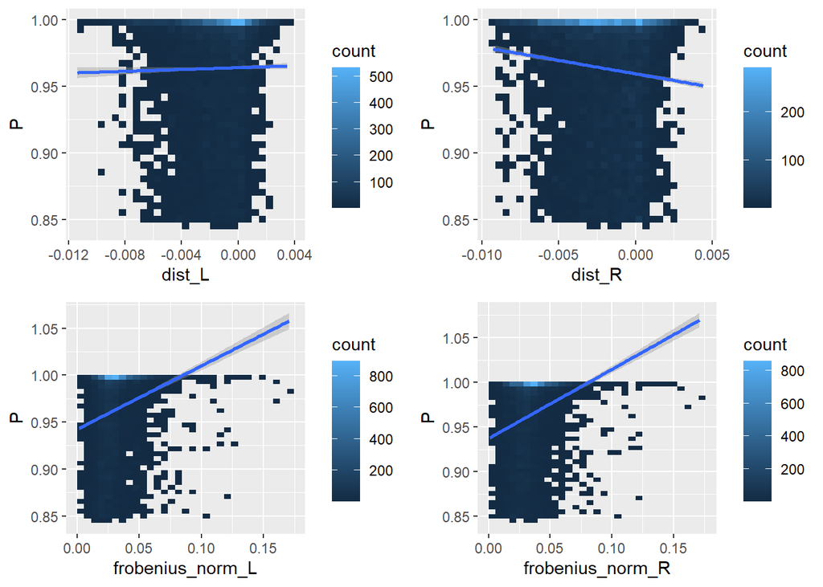

```r
g5 = ggplot(imputed_associations_10000)+
  geom_bin2d(aes(dist_L,P))+
  geom_smooth(aes(dist_L,P), method = "lm")
g6 = ggplot(imputed_associations_10000)+
  geom_bin2d(aes(dist_R,P))+
  geom_smooth(aes(dist_R,P), method = "lm")
g7 = ggplot(imputed_associations_10000)+
  geom_bin2d(aes(frobenius_norm_L,P))+
  geom_smooth(aes(frobenius_norm_L,P), method = "lm")
g8 = ggplot(imputed_associations_10000)+
  geom_bin2d(aes(frobenius_norm_R,P))+
  geom_smooth(aes(frobenius_norm_R,P), method = "lm")
ggarrange(g5,g6, g7, g8)
```

Impact on the first eigenvalue

```r
str(svd_data[[1]])
```

```
## List of 3
##  $ L      : num [1:829, 1:12] -0.4221 -0.103 -0.8423 -0.0521 -0.1413 ...
##  $ t_R    : num [1:1081, 1:12] -0.0399 -0.0399 -0.0399 -0.7404 -0.5191 ...
##  $ egein_V: num 162
```

```r
l1 = sapply(svd_data, function(x) x$egein_V)
head(l1)
```

```
## [1] 162.4947 162.4953 162.4941 162.4956 162.4954 162.4953
```

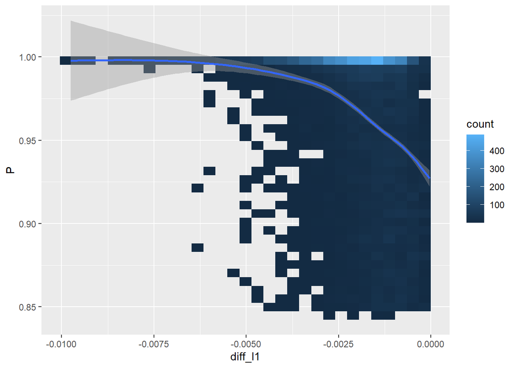

```r
diff_l1 = l1-svd(ntw_trefle)$d[1]
imputed_associations_10000$diff_l1 = diff_l1
ggplot(imputed_associations_10000)+
  geom_bin2d(aes(diff_l1,P))+
  geom_smooth(aes(diff_l1,P))
```

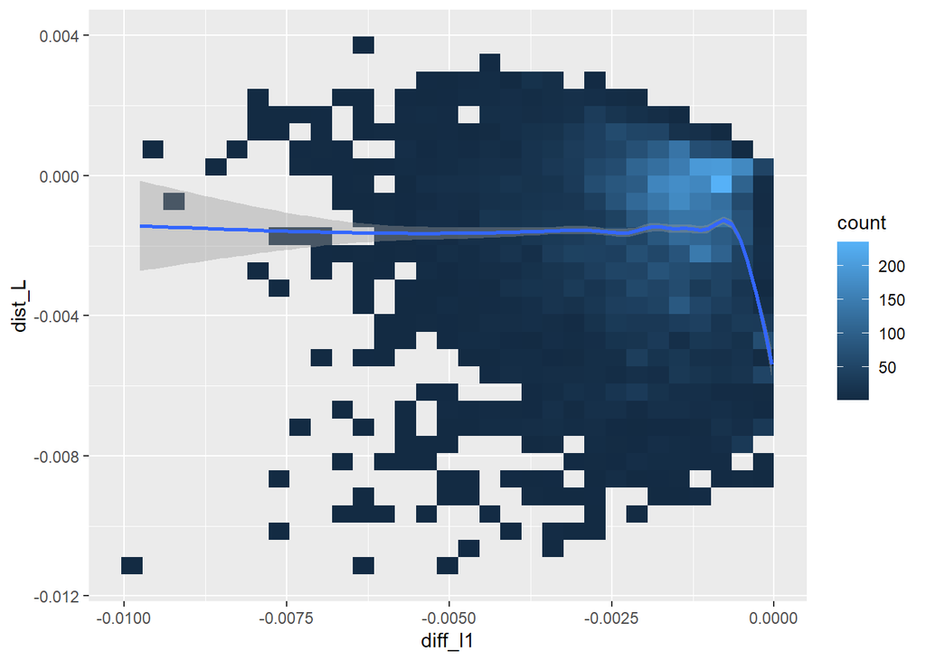

```r
ggplot(imputed_associations_10000)+
  geom_bin2d(aes(diff_l1,dist_L))+
  geom_smooth(aes(diff_l1,dist_L))
```

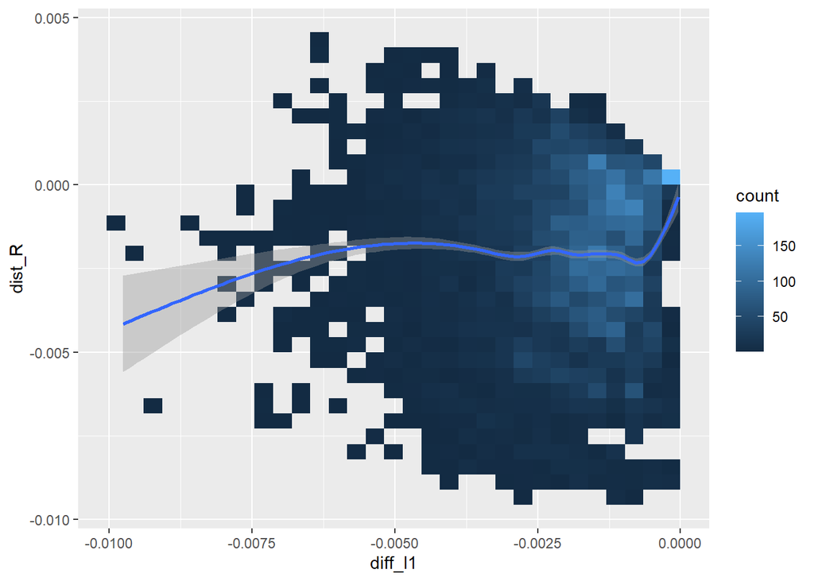

```r
ggplot(imputed_associations_10000)+
  geom_bin2d(aes(diff_l1,dist_R))+
  geom_smooth(aes(diff_l1,dist_R))
```

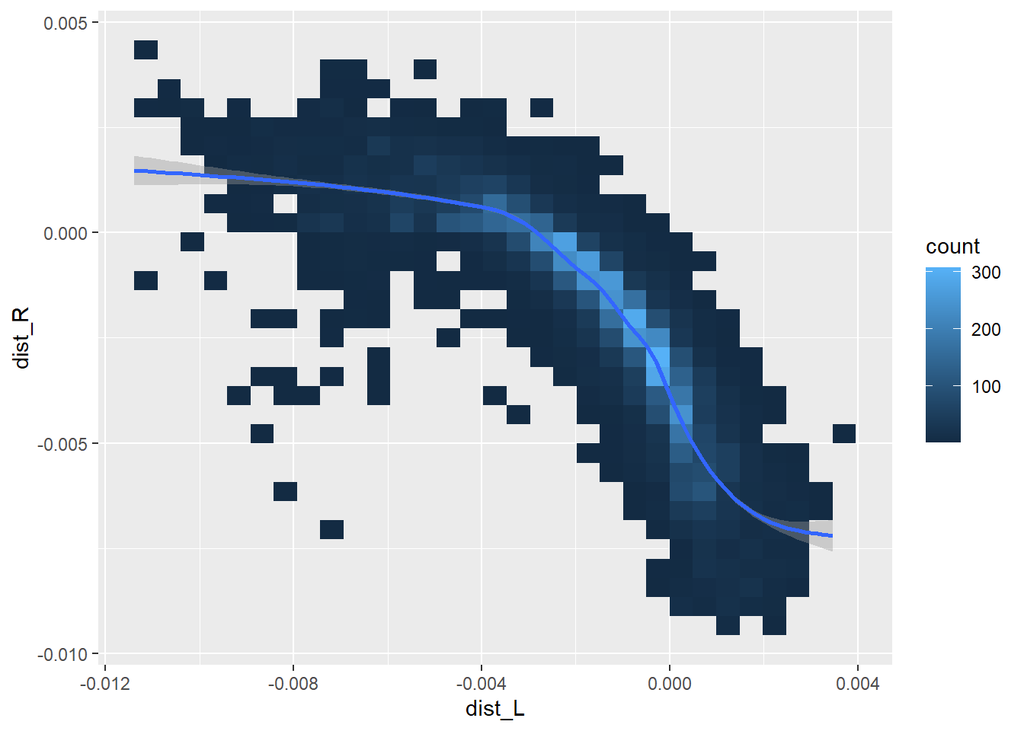

```r
ggplot(imputed_associations_10000)+
  geom_bin2d(aes(dist_L,dist_R))+
  geom_smooth(aes(dist_L,dist_R))
```

```r
library(car)
fit_maxsum = lm(P~dist_L+dist_R, data =imputed_associations_10000 )


open3d()
```

```
## wgl
##   1
```

```r
with(imputed_associations_10000,
     plot3d(dist_L,
          dist_R,
       P, xlab = "L norm diff" ,
       ylab = "R norm diff", zlab ="P"))

planes3d(fit_maxsum$coefficients[2],fit_maxsum$coefficients[3], -1, fit_maxsum$coefficients[1],
         alpha = 0.5, col = "blue")


fit_allsum = lm(P~dist_elementwise_L+dist_elementwise_R, data =imputed_associations_10000 )
open3d()
```

```
## wgl
##   2
```

```r
with(imputed_associations_10000,
     plot3d(dist_elementwise_L,
          dist_elementwise_R,
       P, xlab = "L sum diff" ,
       ylab = "R sum diff", zlab ="P"))

planes3d(fit_allsum$coefficients[2],fit_allsum$coefficients[3], -1, fit_allsum$coefficients[1],
         alpha = 0.5, col = "blue")

fit_fnorm = lm(P~frobenius_norm_L+frobenius_norm_R, data =imputed_associations_10000 )
open3d()
```

```
## wgl
##   3
```

```r
with(imputed_associations_10000,
     plot3d(frobenius_norm_L,
          frobenius_norm_R,
       P, xlab = "L sum diff" ,
       ylab = "R sum diff", zlab ="P"))

planes3d(fit_fnorm$coefficients[2],fit_fnorm$coefficients[3], -1, fit_fnorm$coefficients[1],
         alpha = 0.5, col = "blue")
```

###Link importance metric idea Main idea is that disturbing the network and using SVD-RGDP seems to be a long path to extrapolate importance of interactions. Maybe all the informations are already présent in the basic network and there is no nedd to induce modification on a link to see its importance

An idea to make a metric of link importance is to use the propertie that powers a n of ntw matrices give numbers of path between 2 nodes of lenght n. This propertie give use how many time a node will impact an other node with n intermediary nodes.
$$(A^n)_{ij} =$$
nbrs of diff walk of length n between i an j 10.1103/PhysRevE.77.036111 show that based on this we can calulate the communicability between nodes using teh exponential of A
$$(e^{A})_{ij}$$
####First idea
$$C_{pq} =
\sum_k\frac{1}{\lambda_1}^k*A^k$$

```r
link.importance<- function(A, deepness){

  # scaling value given the first eigen value
  lambda1 = eigen(A)$values[1]
  alpha = 1/lambda1

  #
  D = diag(eigen(A)$values)
  P = eigen(A)$vectors
  d = D
  out = A
  for (k in 1:deepness){
    d =(alpha**k)*D**k
    out = out + P %*% d %*% solve(P)
  }

  return(out)
}
```

####Paper more detail and mathematical based idea
$$G_{pq} = \frac{1}{s!}P^{(s)}_{pq} +
\sum_{k>s}\frac{1}{k!}W^{(k)}_{pq}$$
with $P^{(s)}_{pq}$ : nbr of the shortest path between p and q with a lenght s $W^{(k)}_{pq}$ : nbr of walks connecting p and q with a lenght k > s weight in decreasing order of the length of the walk.

this give :
$$G_{p q}=\sum_{k=0}^{\infty} \frac{\left(\mathbf{A}^k\right)_{p q}}{k
!}=\left(e^{\mathbf{A}}\right)_{p q}$$
This formula is compute with the next function for a test matrice A

```
##      [,1] [,2] [,3] [,4]
## [1,]    0    0    1    0
## [2,]    0    0    1    1
## [3,]    1    1    0    0
## [4,]    0    1    0    0
```

```r
link.importance.2<- function(A, deepness){

  d = eigen(A)$values
  P = eigen(A)$vectors
  out = 0
  k=0
  for (k in 0:deepness){
    #d = D**k
      out = out + 1/factorial(k)*(P %*%  diag(d**k) %*% solve(P)) # A + A²
                                     # A + P%*%D
  }

  return(out)
}
link.importance.2(A, 5)
```

```
##           [,1]     [,2]     [,3]      [,4]
## [1,] 1.5833333 0.625000 1.375000 0.1916667
## [2,] 0.6250000 2.208333 1.566667 1.3750000
## [3,] 1.3750000 1.566667 2.208333 0.6250000
## [4,] 0.1916667 1.375000 0.625000 1.5833333
```

```r
link.importance.2(A, 15)
```

```
##           [,1]      [,2]      [,3]      [,4]
## [1,] 1.5906098 0.6366474 1.3776753 0.1933132
## [2,] 0.6366474 2.2272572 1.5709886 1.3776753
## [3,] 1.3776753 1.5709886 2.2272572 0.6366474
## [4,] 0.1933132 1.3776753 0.6366474 1.5906098
```

```r
link.importance.2(A, 20)
```

```
##           [,1]      [,2]      [,3]      [,4]
## [1,] 1.5906098 0.6366474 1.3776753 0.1933132
## [2,] 0.6366474 2.2272572 1.5709886 1.3776753
## [3,] 1.3776753 1.5709886 2.2272572 0.6366474
## [4,] 0.1933132 1.3776753 0.6366474 1.5906098
```

```r
link.importance.2(A, 40)
```

```
##           [,1]      [,2]      [,3]      [,4]
## [1,] 1.5906098 0.6366474 1.3776753 0.1933132
## [2,] 0.6366474 2.2272572 1.5709886 1.3776753
## [3,] 1.3776753 1.5709886 2.2272572 0.6366474
## [4,] 0.1933132 1.3776753 0.6366474 1.5906098
```

```r
G=0
for(i in 1:ncol(eigen(A)$vectors)){
  temp = eigen(A)$vectors[,i]%*%t(eigen(A)$vectors[,i])*exp(eigen(A)$values[i])
  G = G + temp
}
G
```

```
##           [,1]      [,2]      [,3]      [,4]
## [1,] 1.5906098 0.6366474 1.3776753 0.1933132
## [2,] 0.6366474 2.2272572 1.5709886 1.3776753
## [3,] 1.3776753 1.5709886 2.2272572 0.6366474
## [4,] 0.1933132 1.3776753 0.6366474 1.5906098
```

As we can see link.importance.2 function is an aproximation of the communicability. It is possible to express it in the form of eigenvector and eigenvalues as follow:
$$G_{pq}=\sum^n_{j=1}\varphi_j(p)\varphi_j(q)e^{\lambda_j}$$

```r
communicabiliy<- function(A){

  d = eigen(A)$values
  P = eigen(A)$vectors
  G=0
  for(i in 1:length(d)){
  phi = P[,i]/norm(P[,i],"2")
  temp = phi%*%t(phi)*exp(d[i])
  G = G + temp
}
  rownames(G)= rownames(A)
  colnames(G)= colnames(A)
  return(G)
}
communicabiliy(A)
```

```
##           [,1]      [,2]      [,3]      [,4]
## [1,] 1.5906098 0.6366474 1.3776753 0.1933132
## [2,] 0.6366474 2.2272572 1.5709886 1.3776753
## [3,] 1.3776753 1.5709886 2.2272572 0.6366474
## [4,] 0.1933132 1.3776753 0.6366474 1.5906098
```

####Now on the real matrix

Do apply this method we need to have a square matrix. This might be probelmatic, for exemple the connectance of the bipartie form and unipartie form are not the same. **A interesting idea could be to apply this kind of method to non-square matrix (if possible)**

```r
ntw_trefle = matrix.associations(trefle$virus, trefle$host)
sum(ntw_trefle)/(ncol(ntw_trefle)*nrow(ntw_trefle))
```

```
## [1] 0.09082753
```

```r
uni_ntw_trefle = matrix.associations.uni(trefle$virus, trefle$host)
sum(uni_ntw_trefle)/(ncol(uni_ntw_trefle)*nrow(uni_ntw_trefle))
```

```
## [1] 0.04462323
```

First idea with the use of the first eigenvalue weight path length

```r
importance_matrix = link.importance(uni_ntw_trefle,deepness= 5)

imputed_associations_10000$importance = 0
for(n in 1:nrow(imputed_associations_10000)){
  ID = c(which(rownames(importance_matrix) == imputed_associations_10000$virus[n]),
         which(colnames(importance_matrix) == imputed_associations_10000$host[n]))
  imputed_associations_10000$importance[n] = importance_matrix[ID[1],ID[2]]
}
```

2nd approach with exponential of A

```r
G_trefle = communicabiliy(uni_ntw_trefle)
str(G_trefle)
```

```
##  num [1:1910, 1:1910] 6.29e+67 2.88e+67 4.08e+67 5.27e+67 4.10e+67 ...
##  - attr(*, "dimnames")=List of 2
##   ..$ : chr [1:1910] "Acinonyx jubatus" "Akodon montensis" "Anoura geoffroyi" "Apodemus agrarius" ...
##   ..$ : chr [1:1910] "Acinonyx jubatus" "Akodon montensis" "Anoura geoffroyi" "Apodemus agrarius" ...
```

```r
imputed_associations_10000$communicabiliy_spectre = 0
for(n in 1:nrow(imputed_associations_10000)){
  ID = c(which(rownames(G_trefle) == imputed_associations_10000$virus[n]),
         which(colnames(G_trefle) == imputed_associations_10000$host[n]))
  imputed_associations_10000$communicabiliy_spectre[n] = G_trefle[ID[1],ID[2]]
}
str(imputed_associations_10000)
```

```
## 'data.frame':    10000 obs. of  17 variables:
##  $ X                     : int  5 17 27 34 37 60 72 75 82 88 ...
##  $ host                  : Factor w/ 950 levels "Abrothrix longipilis",..: 10 464 308 734 341 945 308 853 692 692 ...
##  $ virus                 : Factor w/ 708 levels "Acara orthobunyavirus",..: 700 417 113 511 704 28 303 85 177 215 ...
##  $ evidence              : num  1.71 1.71 1.71 1.71 1.71 ...
##  $ P                     : num  0.847 0.847 0.847 0.847 0.847 ...
##  $ dist_L                : num  -0.00152 -0.0005 -0.00369 -0.00118 -0.0035 ...
##  $ dist_R                : num  -0.001545 -0.0023 0.000806 -0.001269 0.00055 ...
##  $ dist_elementwise_L    : num  0.624 1.017 1.602 0.796 0.737 ...
##  $ dist_elementwise_R    : num  0.664 1.215 2.002 1.068 0.826 ...
##  $ subset_asso           : int  5 17 27 34 37 60 72 75 82 88 ...
##  $ dist_L2               : num  222523 222523 222523 222523 222523 ...
##  $ dist_R2               : num  359151 359151 359151 359151 359151 ...
##  $ frobenius_norm_L      : num  0.019 0.025 0.0366 0.0222 0.0231 ...
##  $ frobenius_norm_R      : num  0.02 0.0301 0.036 0.0223 0.0188 ...
##  $ diff_l1               : num  -0.002 -0.00147 -0.00261 -0.00109 -0.00136 ...
##  $ importance            : num  1.01 1.01 1.01 1.01 1.01 ...
##  $ communicabiliy_spectre: num  3.74e+67 2.76e+67 4.90e+67 2.05e+67 2.55e+67 ...
```

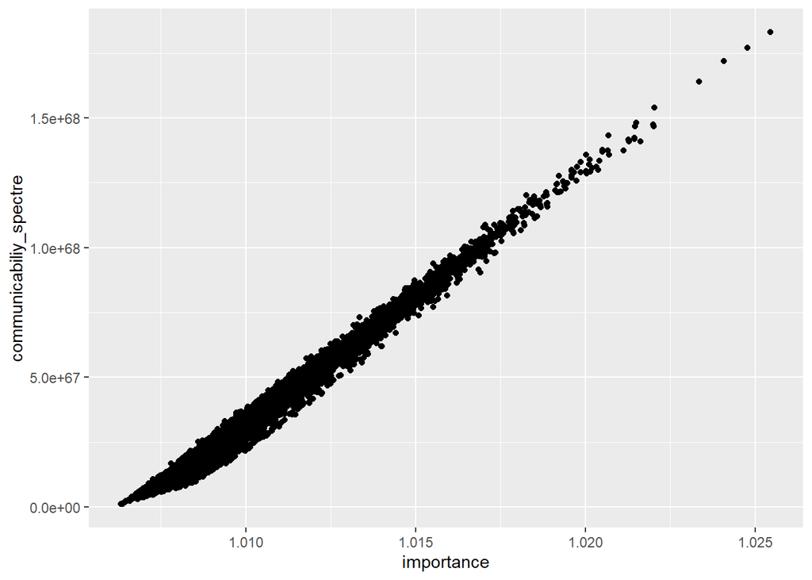

```r
ggplot(imputed_associations_10000, aes(importance,communicabiliy_spectre))+
  geom_point()
```

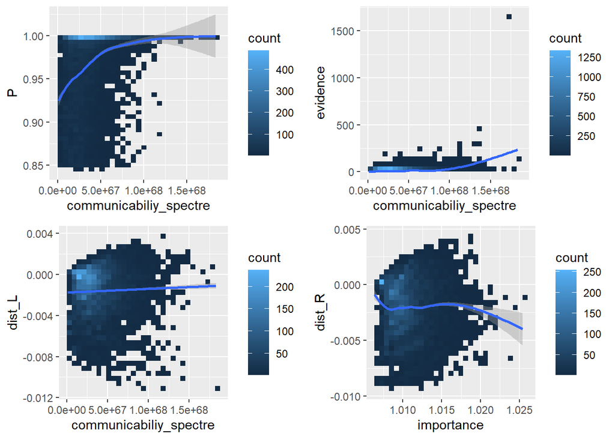

```r
g5=ggplot(imputed_associations_10000, aes(communicabiliy_spectre,P))+
  geom_bin2d()+
  geom_smooth()
g6=ggplot(imputed_associations_10000, aes(communicabiliy_spectre,evidence))+
  geom_bin2d()+
  geom_smooth()
g7=ggplot(imputed_associations_10000, aes(communicabiliy_spectre,dist_L))+
  geom_bin2d()+
  geom_smooth(method = "lm")
g8=ggplot(imputed_associations_10000, aes(importance,dist_R))+
  geom_bin2d()+
  geom_smooth()

ggarrange(g5,g6,g7,g8)
```

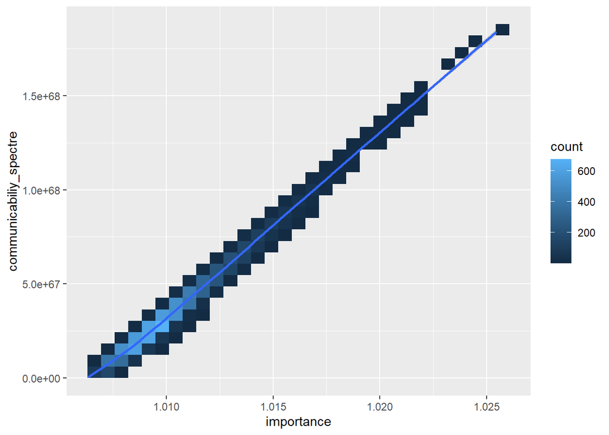

```r
ggplot(imputed_associations_10000, aes(importance,communicabiliy_spectre))+
  geom_bin2d()+
  geom_smooth()
```

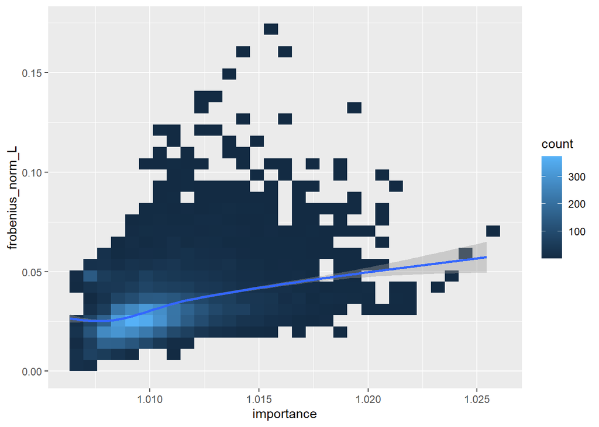

```r
ggplot(imputed_associations_10000, aes(importance,frobenius_norm_L))+
  geom_bin2d()+
  geom_smooth()
```

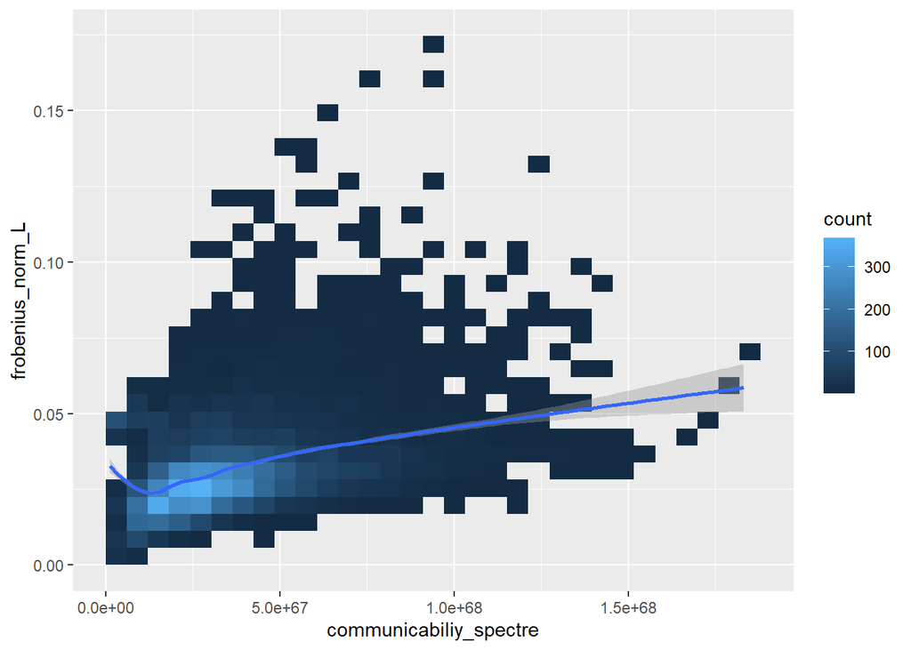

```r
ggplot(imputed_associations_10000, aes(communicabiliy_spectre,frobenius_norm_L))+
  geom_bin2d()+
  geom_smooth()
```